# Visualizing FordGoBike Data

#### define5: measuring the destince from the start_station_latitude, start_station_longitude, end_station_latitude, and end_station_longitude columns.

Using the haversine formula which is used to calculate the shortest distance between tow points in a circlare shape. Moreover, I used Google for providing a way to figure code out. Therefore, the reference is listed in the sources at the end of this document

#### code5

```python
#code5
# vectorized haversine function
def haversine(lat1, lon1, lat2, lon2, to_radians=True, earth_radius=6371):
    """
    slightly modified version: of http://stackoverflow.com/a/29546836/2901002

    Calculate the great circle distance between two points
    on the earth (specified in decimal degrees or in radians)

    All (lat, lon) coordinates must have numeric dtypes and be of equal length.

    """
    if to_radians:
        lat1, lon1, lat2, lon2 = np.radians([df_clean['start_station_latitude'], df_clean['start_station_longitude'], df_clean['end_station_latitude'],  df_clean['end_station_longitude']])

    a = np.sin((lat2-lat1)/2.0)**2 + \
        np.cos(lat1) * np.cos(lat2) * np.sin((lon2-lon1)/2.0)**2

    return earth_radius * 2 * np.arcsin(np.sqrt(a))

## km unit was used because the earth radius was applied in km.
df_clean['dist_km'] = haversine(df_clean['start_station_latitude'].shift(), df_clean['start_station_longitude'].shift(),
                 df.loc[1:, 'start_station_latitude'], df.loc[1:, 'start_station_longitude'])
```

#### test5

```python
#test5
df_clean.dist_km.sample(10)
```

```
421309    2.493455
145717    3.368189
126804    0.857486
420868    0.307112
88330     3.258560
259869    1.325407
367712    1.218016
75410     2.793210
329011    2.237958
325574    2.091947
Name: dist_km, dtype: float64
```

```python
df_clean.end_time.describe()
```

```
count                         449234
unique                        449218
top       2017-10-27 17:32:13.649000
freq                               2
first     2017-06-28 09:52:55.338000
last      2018-01-01 15:12:50.245000
Name: end_time, dtype: object
```

```python
df_clean.start_time.describe()
```

```
count                         449234
unique                        449224
top       2017-12-04 17:51:03.433000
freq                               2
first     2017-06-28 09:47:36.347000
last      2017-12-31 23:59:01.261000
Name: start_time, dtype: object
```

#### define6: Getting the bike tripe duration in min insted of sec which can help me draw visuals.

#### Code6

```python
# Duration in seconds to duration in minutes
df_clean['duration_min'] = (df_clean['duration_sec']/60).astype(int)
```

#### test6

```python
# Looking at duration in sec and min
df_clean.sample(5)
```

|  | duration_sec | start_time | end_time | start_station_id | start_station_name | start_station_latitude | start_station_longitude | end_station_id | end_station_name | end_station_latitude | end_station_longitude | bike_id | user_type | member_birth_year | member_gender | member_age | dist_km | duration_min |
| --- | --- | --- | --- | --- | --- | --- | --- | --- | --- | --- | --- | --- | --- | --- | --- | --- | --- | --- |
| 215201 | 537 | 2017-10-23 09:22:15.165 | 2017-10-23 09:31:12.793 | 25 | Howard St at 2nd St | 37.787522 | -122.397405 | 33 | Golden Gate Ave at Hyde St | 37.781650 | -122.415408 | 3034 | Subscriber | 1967.0 | Male | 50 | 1.711530 | 8 |
| 255062 | 602 | 2017-10-11 08:32:47.470 | 2017-10-11 08:42:50.165 | 24 | Spear St at Folsom St | 37.789677 | -122.390428 | 93 | 4th St at Mission Bay Blvd S | 37.770407 | -122.391198 | 700 | Subscriber | 1981.0 | Male | 36 | 2.143716 | 10 |
| 286726 | 791 | 2017-10-02 15:06:39.310 | 2017-10-02 15:19:50.935 | 160 | West Oakland BART Station | 37.805318 | -122.294837 | 213 | 32nd St at Adeline St | 37.823847 | -122.281193 | 30 | Subscriber | 1968.0 | Female | 49 | 2.383588 | 13 |
| 392400 | 618 | 2017-08-31 09:29:38.157 | 2017-08-31 09:39:57.048 | 113 | Franklin Square | 37.764555 | -122.410345 | 75 | Market St at Franklin St | 37.773793 | -122.421239 | 817 | Subscriber | 1965.0 | Male | 52 | 1.404332 | 10 |
| 336204 | 2335 | 2017-09-18 09:09:59.472 | 2017-09-18 09:48:54.749 | 16 | Steuart St at Market St | 37.794130 | -122.394430 | 8 | The Embarcadero at Vallejo St | 37.799953 | -122.398525 | 1095 | Subscriber | 1967.0 | Male | 50 | 0.740744 | 38 |

### Saving data set

```python
## As CSV
df_clean.to_csv('FordGo_2017.csv', index= False)
```

```python
df_clean.dtypes
```

```
duration_sec                        int64
start_time                 datetime64[ns]
end_time                   datetime64[ns]
start_station_id                   object
start_station_name                 object
start_station_latitude            float64
start_station_longitude           float64
end_station_id                     object
end_station_name                   object
end_station_latitude              float64
end_station_longitude             float64
bike_id                            object
user_type                        category
member_birth_year                 float64
member_gender                    category
member_age                          int32
dist_km                           float64
duration_min                        int32
dtype: object
```

### What is the structure of your dataset?

> The FordGoBike 2017 is a straightforward and easy to understand and work with data set. This data set has been collected efficiently, providing an amazing collection of data to draw conclusions.

> This data was collected between Jun and Dec 2017. it has around 450000 rows, which consist of bike rides in San Francisco, California, US.

> The columns are as follows:
> - Trip Duration (seconds)
> - Start and End Time and Date
> - Start Station ID
> - Start Station Name
> - Start Station Latitude
> - Start Station Longitude
> - End Station ID
> - End Station Name
> - End Station Latitude
> - End Station Longitude
> - Bike ID
> - User Type
> - Member Year Birth
> - Member Gender

> I added the following columns:
> - Member Age
> - Distance (km)
> - Trip Duration (minuts)

### What is/are the main feature(s) of interest in your dataset?

> The main features of interest include data related to the start and end of the rides. This can be used to know whether the bikes are in high or low demand, how much the bike is consumed and used, and what type of people are riding the bikes. These features can be used to make business decisions such as which age group to target in marketing campaigns, which day of the week bikes should be most available, what user type use more, or what the prices should be to make profits after consumption services.

### What features in the dataset do you think will help support your investigation into your feature(s) of interest?

> I expect that the start and end times and dates can be utilized in various effective ways. I will be using the customer related data, such as age, gender,etc , as well as the distance Conversely with time- based information to understand the user-driven data behind each ride.

## Univariate Exploration

> In this section, I'll investigate the distributions of individual variables. Also, I'll be looking at the relationships between variables.

```python
df_clean.start_time.dt.to_period('M').unique()
```

```
<PeriodArray>
['2017-12', '2017-11', '2017-10', '2017-09', '2017-08', '2017-07', '2017-06']
Length: 7, dtype: period[M]
```

```python
# Before we visualize our data, let's see what kind of numbers we're looking at
df_clean.start_time.dt.to_period('M').describe()
```

```
count      449234
unique          7
top       2017-10
freq        94525
Name: start_time, dtype: object
```

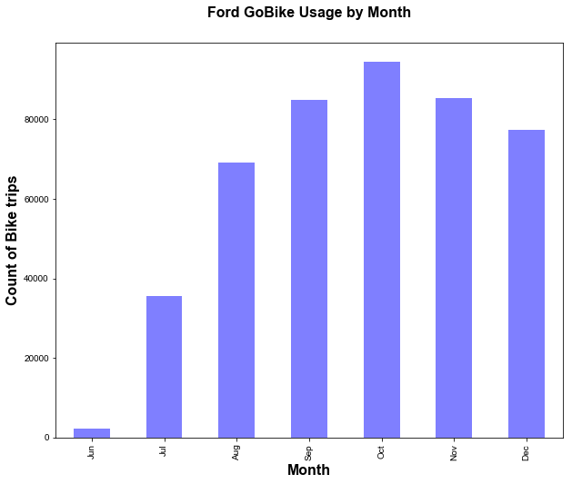

```python
# Monthly usage of the Ford Go Bike system
df_clean.groupby(df_clean.start_time.dt.to_period('M'))['bike_id'].count().plot(kind= 'bar', figsize= (10,8), color= 'b', alpha= 0.5)
plt.xticks(np.arange(7), ('Jun', 'Jul', 'Aug', 'Sep', 'Oct', 'Nov', 'Dec'))
sns.set_style("whitegrid")
plt.xlabel('Month', fontsize = 16, fontweight = 'bold')
plt.ylabel('Count of Bike trips',fontsize = 16, fontweight = 'bold')
plt.title('Ford GoBike Usage by Month', y = 1.05, fontsize = 16, fontweight = 'bold')
```

```python
# By having The day of the week with Monday=0, Sunday=6.
df_clean.start_time.dt.dayofweek.unique()
```

```
array([6, 5, 4, 3, 2, 1, 0], dtype=int64)
```

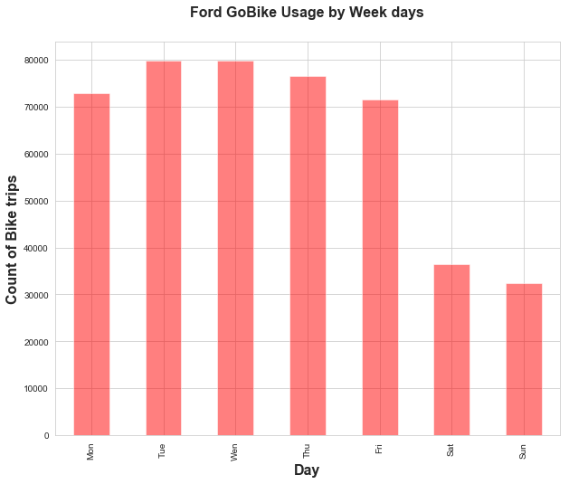

```python
# Days of the week usage of the Ford Go Bike system
df_clean.groupby(df_clean.start_time.dt.dayofweek)['bike_id'].count().plot(kind= 'bar', figsize= (10,8), color= 'r', alpha= 0.5)
plt.xticks(np.arange(7), ('Mon', 'Tue', 'Wen', 'Thu', 'Fri', 'Sat', 'Sun'))
sns.set_style("whitegrid")
plt.xlabel('Day', fontsize = 16, fontweight = 'bold')
plt.ylabel('Count of Bike trips',fontsize = 16, fontweight = 'bold')
plt.title('Ford GoBike Usage by Week days', y = 1.05, fontsize = 16, fontweight = 'bold')
```

> *Observation 2: Tuesdays and Wednesdays seem to be the most popular days for using the FordGo bike system. Nevertheless, Thursdays, Mondays and Fridays are very close to each other’s and very close to the Tues/Weds numbers. The usage reduces sharply on Saturdays and Sundays showing the FordGo bike system is used intensively during working days.

```python
df_clean.start_time.dt.hour.unique()
```

```
array([16, 15, 14, 23, 22, 21, 20, 19, 18, 17, 10, 11, 13, 12,  9,  8,  7,
        6,  5,  3,  2,  1,  0,  4], dtype=int64)
```

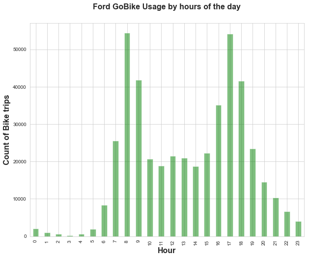

```python
# Hours of the days usage of the Ford Go Bike system
df_clean.groupby(df_clean.start_time.dt.hour)['bike_id'].count().plot(kind= 'bar', figsize= (10,8), color= 'g', alpha= 0.5)
sns.set_style("whitegrid")
plt.xlabel('Hour', fontsize = 16, fontweight = 'bold')
plt.ylabel('Count of Bike trips',fontsize = 16, fontweight = 'bold')
plt.title('Ford GoBike Usage by hours of the day', y = 1.05, fontsize = 16, fontweight = 'bold')
```

> *Observation 3: The bikes trips' data shows that the most usage is during the morning hours of 8-9 AM, and in the afternoon to evening hours from 5-6 PM, which is a typical a go to and back from wok time. This supports the previous observation which suggest that the bikes are being used primarily for working purposes.

```python
df_clean.head()
```

|  | duration_sec | start_time | end_time | start_station_id | start_station_name | start_station_latitude | start_station_longitude | end_station_id | end_station_name | end_station_latitude | end_station_longitude | bike_id | user_type | member_birth_year | member_gender | member_age | dist_km | duration_min |
| --- | --- | --- | --- | --- | --- | --- | --- | --- | --- | --- | --- | --- | --- | --- | --- | --- | --- | --- |
| 0 | 80110 | 2017-12-31 16:57:39.654 | 2018-01-01 15:12:50.245 | 74 | Laguna St at Hayes St | 37.776435 | -122.426244 | 43 | San Francisco Public Library (Grove St at Hyde... | 37.778768 | -122.415929 | 96 | Customer | 1987.0 | Male | 30 | 0.942931 | 1335 |
| 1 | 78800 | 2017-12-31 15:56:34.842 | 2018-01-01 13:49:55.617 | 284 | Yerba Buena Center for the Arts (Howard St at ... | 37.784872 | -122.400876 | 96 | Dolores St at 15th St | 37.766210 | -122.426614 | 88 | Customer | 1965.0 | Female | 52 | 3.069727 | 1313 |
| 4 | 43603 | 2017-12-31 14:23:14.001 | 2018-01-01 02:29:57.571 | 239 | Bancroft Way at Telegraph Ave | 37.868813 | -122.258764 | 247 | Fulton St at Bancroft Way | 37.867789 | -122.265896 | 3167 | Subscriber | 1997.0 | Female | 20 | 0.636339 | 726 |
| 6 | 4507 | 2017-12-31 23:49:28.422 | 2018-01-01 01:04:35.619 | 259 | Addison St at Fourth St | 37.866249 | -122.299371 | 259 | Addison St at Fourth St | 37.866249 | -122.299371 | 3539 | Customer | 1991.0 | Female | 26 | 0.000000 | 75 |
| 12 | 2183 | 2017-12-31 23:52:55.581 | 2018-01-01 00:29:18.743 | 67 | San Francisco Caltrain Station 2 (Townsend St... | 37.776639 | -122.395526 | 24 | Spear St at Folsom St | 37.789677 | -122.390428 | 2311 | Subscriber | 1990.0 | Male | 27 | 1.517348 | 36 |

```python
# Looking at how many seconds most bike trips takes to make a clear visualization
df_clean.duration_sec.describe(percentiles = [.985])
```

```
count    449234.000000
mean        832.867755
std        2524.866433
min          61.000000
50%         556.000000
98.5%      2970.000000
max       86252.000000
Name: duration_sec, dtype: float64
```

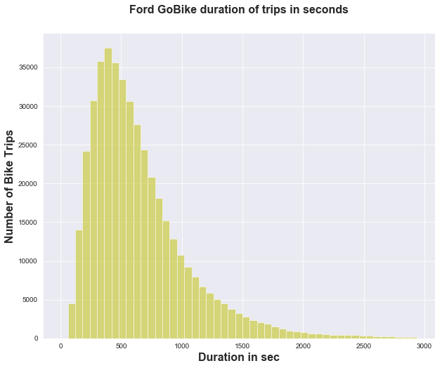

```python
# Duration of the bike rides in seconds
xbins_sec = np.arange(0, 3000, 60)
plt.figure(figsize=(10,8))
plt.hist(data = df_clean, x = 'duration_sec', bins = xbins_sec, color= 'y', alpha= 0.5);
sns.set_style("dark")
plt.xlabel('Duration in sec', fontsize = 16, fontweight = 'bold')
plt.ylabel('Number of Bike Trips',fontsize = 16, fontweight = 'bold')
plt.title('Ford GoBike duration of trips in seconds', y = 1.05, fontsize = 16, fontweight = 'bold')
```

```python
# Looking at how many minutes most bike trips takes to make a clear visualization
df_clean.duration_min.describe(percentiles = [.985])
```

```
count    449234.000000
mean         13.389893
std          42.082262
min           1.000000
50%           9.000000
98.5%        49.000000
max        1437.000000
Name: duration_min, dtype: float64
```

```python
df_clean.duration_min.describe()
```

```
count    449234.000000
mean         13.389893
std          42.082262
min           1.000000
25%           6.000000
50%           9.000000
75%          13.000000
max        1437.000000
Name: duration_min, dtype: float64
```

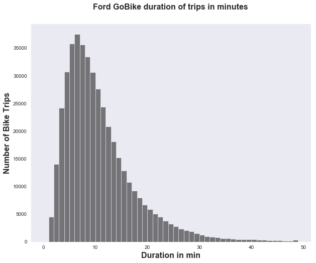

```python
# Duration of the bike rides in minutes
xbins_min = np.arange(0, 50)
plt.figure(figsize=(10,8))
plt.hist(data = df_clean, x = 'duration_min', bins = xbins_min, color= 'k', alpha= 0.5);
sns.set_style("darkgrid")
plt.xlabel('Duration in min', fontsize = 16, fontweight = 'bold')
plt.ylabel('Number of Bike Trips',fontsize = 16, fontweight = 'bold')
plt.title('Ford GoBike duration of trips in minutes', y = 1.05, fontsize = 16, fontweight = 'bold')
```

> *Observation 4: The average trip is around 10 minutes -from the graph where outliers don’t effect a lot- with 75% of trips being under 13 minutes. Furthermore, we can indicate from the graph that most trips are between 6 to 13 minutes, which means the bikes are mostly used for short distances.*

```python
df_clean.dist_km.describe(percentiles= [0.99])
```

```
count    449234.000000
mean          1.601874
std           0.984082
min           0.000000
50%           1.411167
99%           4.685569
max          62.293682
Name: dist_km, dtype: float64
```

```python
df_clean.dist_km.describe()
```

```
count    449234.000000
mean          1.601874
std           0.984082
min           0.000000
25%           0.921188
50%           1.411167
75%           2.072494
max          62.293682
Name: dist_km, dtype: float64
```

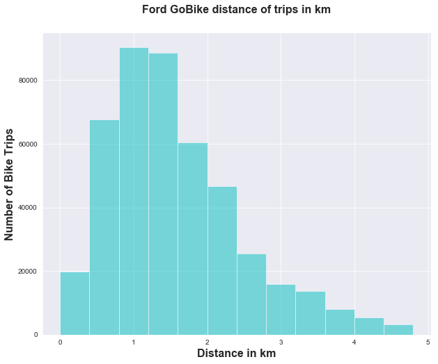

```python
# Distance of the bike rides in km
xbins_dist = np.arange(0, 5, 0.4)
plt.figure(figsize=(10,8))
plt.hist(data = df_clean, x = 'dist_km', bins = xbins_dist, color= 'c', alpha= 0.5);
sns.set_style("dark")
plt.xlabel('Distance in km', fontsize = 16, fontweight = 'bold')
plt.ylabel('Number of Bike Trips',fontsize = 16, fontweight = 'bold')
plt.title('Ford GoBike distance of trips in km', y = 1.05, fontsize = 16, fontweight = 'bold')
```

> *Observation 5: The distance traveled by user in their trips is around 1.6 km, where 75% of rides being 2 km a bit more. Looking at the histogram above most of the rides fall under 2.5 km, with over half of those record a bit more than one km.*

```python
# No need for the percentiles because we already define it and clean it through the cleaning procces.
df_clean.member_age.describe()
```

```
count    449234.000000
mean         36.254475
std           9.816654
min          18.000000
25%          29.000000
50%          34.000000
75%          42.000000
max          66.000000
Name: member_age, dtype: float64
```

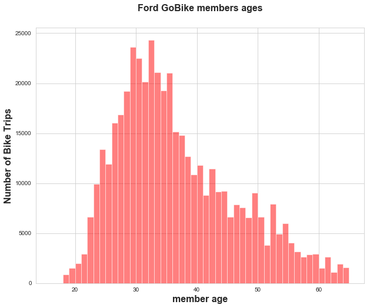

```python
# Member age of the bike rides
xbins_age = np.arange(16, 66)
plt.figure(figsize=(10,8))
plt.hist(data = df_clean, x = 'member_age', bins = xbins_age, color= 'r', alpha= 0.5);
sns.set_style("whitegrid")
plt.xlabel('member age', fontsize = 16, fontweight = 'bold')
plt.ylabel('Number of Bike Trips',fontsize = 16, fontweight = 'bold')
plt.title('Ford GoBike members ages', y = 1.05, fontsize = 16, fontweight = 'bold')
```

```python
df_clean.member_gender.dtypes
```

```
CategoricalDtype(categories=['Female', 'Male', 'Other'], ordered=False)
```

```python
(df_clean.member_gender.value_counts()/ len(df_clean.member_gender)) *100
```

```
Male      76.800732
Female    21.815579
Other      1.383689
Name: member_gender, dtype: float64
```

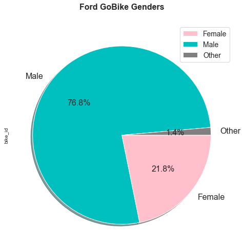

```python
df_clean.groupby(df_clean['member_gender'])['bike_id'].count().plot(kind= 'pie', colors=('pink','c', 'grey'),figsize= (10,8), fontsize = 16,  autopct='%1.1f%%',
counterclock=False, shadow=True)
plt.legend(fontsize = 14)
plt.title('Ford GoBike Genders', y = 1.05, fontsize = 16, fontweight = 'bold')
```

```python
df_clean.user_type.unique()
```

```
[Customer, Subscriber]
Categories (2, object): [Customer, Subscriber]
```

> *Observation 7: The pie chart above, illustrates that the majority of users of the FordGo bike system, in terms of members gender, are Male, representing almost 77% of the total users. On the other hand, Females make around 21% of the total. Finally, the others make around 1.5%*

```python
df_clean.user_type.unique()
```

```
[Customer, Subscriber]
Categories (2, object): [Customer, Subscriber]
```

```python
df_clean.user_type.value_counts()
```

```
Subscriber    400701
Customer       48533
Name: user_type, dtype: int64
```

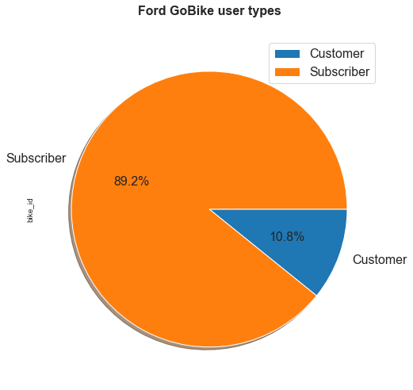

```python
# User types visuals
df_clean.groupby(df_clean['user_type'])['bike_id'].count().plot(kind= 'pie', figsize= (10,8), fontsize = 16, autopct='%1.1f%%',
counterclock=False, shadow=True)
plt.legend(fontsize = 16)
plt.title('Ford GoBike user types', y = 1.05, fontsize = 16, fontweight = 'bold')
```

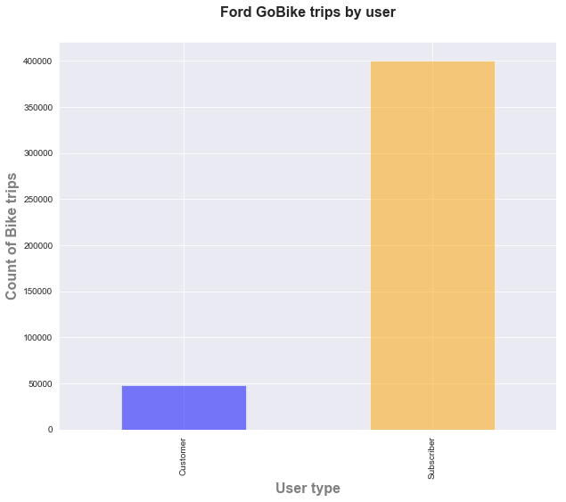

```python
# User types visuals
df_clean.groupby(df_clean.user_type)['bike_id'].count().plot(kind= 'bar', figsize= (10,8), color= ('blue','orange'), alpha= 0.5)
sns.set_style("darkgrid")
plt.xlabel('User type', fontsize = 16, fontweight = 'bold', color='grey')
plt.ylabel('Count of Bike trips',fontsize = 16, fontweight = 'bold',color='grey')
plt.title('Ford GoBike trips by user', y = 1.05, fontsize = 16, fontweight = 'bold')
```

> *Observation 8: The previous two charts (pie chart, and bar chart) at the top, illustrates that the majority of users of the FordGo bike system, in terms of user types, are Subscriber, representing almost 90% of the total users. Where Customers takes only 10%*

## Discuss the distribution(s) of your variable(s) of interest. Were there any unusual points? Did you need to perform any transformations?

> Fortunately, due to thorough wrangling, assessing, and cleaning efforts there were no big surprises during the exploratory and visualization phase. The duration of the bike ride and the distance made a little trouble since there were some outliers I didn't expect.

## Of the features you investigated, were there any unusual distributions? Did you perform any operations on the data to tidy, adjust, or change the form of the data? If so, why did you do this?

> Nothing seems out of the normal expectations for a bike sharing system in a major city, like San Francisco. Lately, the data reveals that adults in the average working age range are the primary user base for the bike system, and they use the bikes on their daily commutes probably for a working purpose.

> Make sure that, after every plot or related series of plots, that you include a Markdown cell with comments about what you observed, and what you plan on investigating next.

## Bivariate Exploration

> In this section, I'll investigate the relationships between pairs of variables in data.

```python
df_clean.user_type.value_counts()
```

```
Subscriber    400701
Customer       48533
Name: user_type, dtype: int64
```

```python
df_clean.head()
```

|  | duration_sec | start_time | end_time | start_station_id | start_station_name | start_station_latitude | start_station_longitude | end_station_id | end_station_name | end_station_latitude | end_station_longitude | bike_id | user_type | member_birth_year | member_gender | member_age | dist_km | duration_min |
| --- | --- | --- | --- | --- | --- | --- | --- | --- | --- | --- | --- | --- | --- | --- | --- | --- | --- | --- |
| 0 | 80110 | 2017-12-31 16:57:39.654 | 2018-01-01 15:12:50.245 | 74 | Laguna St at Hayes St | 37.776435 | -122.426244 | 43 | San Francisco Public Library (Grove St at Hyde... | 37.778768 | -122.415929 | 96 | Customer | 1987.0 | Male | 30 | 0.942931 | 1335 |
| 1 | 78800 | 2017-12-31 15:56:34.842 | 2018-01-01 13:49:55.617 | 284 | Yerba Buena Center for the Arts (Howard St at ... | 37.784872 | -122.400876 | 96 | Dolores St at 15th St | 37.766210 | -122.426614 | 88 | Customer | 1965.0 | Female | 52 | 3.069727 | 1313 |
| 4 | 43603 | 2017-12-31 14:23:14.001 | 2018-01-01 02:29:57.571 | 239 | Bancroft Way at Telegraph Ave | 37.868813 | -122.258764 | 247 | Fulton St at Bancroft Way | 37.867789 | -122.265896 | 3167 | Subscriber | 1997.0 | Female | 20 | 0.636339 | 726 |
| 6 | 4507 | 2017-12-31 23:49:28.422 | 2018-01-01 01:04:35.619 | 259 | Addison St at Fourth St | 37.866249 | -122.299371 | 259 | Addison St at Fourth St | 37.866249 | -122.299371 | 3539 | Customer | 1991.0 | Female | 26 | 0.000000 | 75 |
| 12 | 2183 | 2017-12-31 23:52:55.581 | 2018-01-01 00:29:18.743 | 67 | San Francisco Caltrain Station 2 (Townsend St... | 37.776639 | -122.395526 | 24 | Spear St at Folsom St | 37.789677 | -122.390428 | 2311 | Subscriber | 1990.0 | Male | 27 | 1.517348 | 36 |

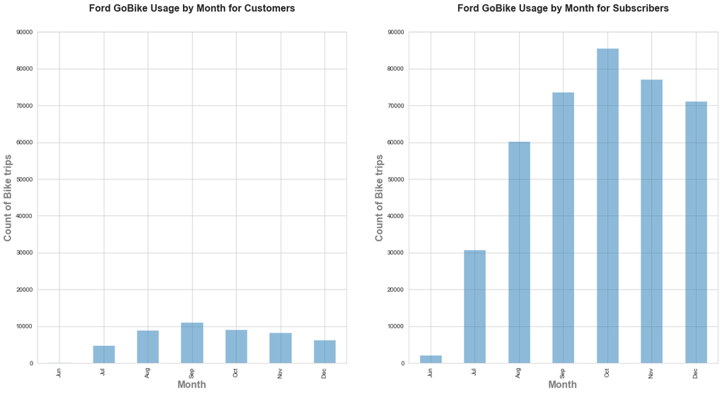

```python
# User types visuals

plt.subplot(1, 2, 1)
df_clean.query('user_type == "Customer"').groupby(df_clean.start_time.dt.to_period('M'))['bike_id'].count().plot(kind= 'bar', figsize= (20,10), alpha= 0.5).set_ylim(0,90000)
plt.xticks(np.arange(7), ('Jun', 'Jul', 'Aug', 'Sep', 'Oct', 'Nov', 'Dec'))
plt.xlabel('Month', fontsize = 16, fontweight = 'bold', color= 'grey')
plt.ylabel('Count of Bike trips',fontsize = 16, fontweight = 'bold', color= 'grey')
plt.title('Ford GoBike Usage by Month for Customers', y = 1.05, fontsize = 16, fontweight = 'bold')


plt.subplot(1, 2, 2)
df_clean.query('user_type == "Subscriber"').groupby(df_clean.start_time.dt.to_period('M'))['bike_id'].count().plot(kind= 'bar', figsize= (20,10), alpha= 0.5).set_ylim(0,90000)
plt.xticks(np.arange(7), ('Jun', 'Jul', 'Aug', 'Sep', 'Oct', 'Nov', 'Dec'))
plt.xlabel('Month', fontsize = 16, fontweight = 'bold', color= 'grey')
plt.ylabel('Count of Bike trips',fontsize = 16, fontweight = 'bold', color= 'grey')
plt.title('Ford GoBike Usage by Month for Subscribers', y = 1.05, fontsize = 16, fontweight = 'bold')
```

> *Observation 1: The beaning of Summer months are the worst for the bike sharing system, especially June, for both groups. what can be determined by the hot weather and holiday season.*

> *Customers: demand is high in Fall, reaching its peak in September. Customers are most probably tourists, or the occasional riders who visit San Francisco.*

> *Subscribers: the highest demand is from September till December, reaching its peak in October. Subscribers are most likely riders using the bikes for their daily commute.*

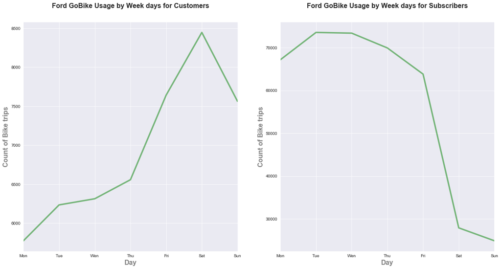

```python
# Customer Usage by Weekday vs. Subscriber Usage by Weekday


plt.subplot(1, 2, 1)
df_clean.query('user_type == "Customer"').groupby(df_clean.start_time.dt.dayofweek)['bike_id'].count().plot(kind= 'line', color= 'green', linewidth= 3.5, figsize= (20,10), alpha= 0.5)
plt.xticks(np.arange(7), ('Mon', 'Tue', 'Wen', 'Thu', 'Fri', 'Sat', 'Sun'))
sns.set_style("darkgrid")
plt.xlabel('Day', fontsize = 16, fontweight = 'bold', color= 'grey')
plt.ylabel('Count of Bike trips',fontsize = 16, fontweight = 'bold', color= 'grey')
plt.title('Ford GoBike Usage by Week days for Customers', y = 1.05, fontsize = 16, fontweight = 'bold')


plt.subplot(1, 2, 2)
df_clean.query('user_type == "Subscriber"').groupby(df_clean.start_time.dt.dayofweek)['bike_id'].count().plot(kind= 'line', color= 'green', linewidth= 3.5, figsize= (20,10), alpha= 0.5)
plt.xticks(np.arange(7), ('Mon', 'Tue', 'Wen', 'Thu', 'Fri', 'Sat', 'Sun'))
sns.set_style("darkgrid")
plt.xlabel('Day', fontsize = 16, fontweight = 'bold', color= 'grey')
plt.ylabel('Count of Bike trips',fontsize = 16, fontweight = 'bold', color= 'grey')
plt.title('Ford GoBike Usage by Week days for Subscribers', y = 1.05, fontsize = 16, fontweight = 'bold')
```

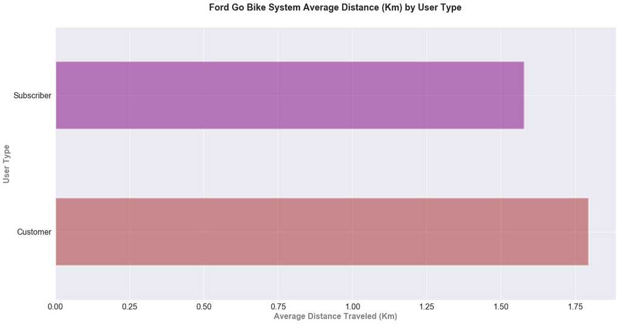

```python
df_clean.query('user_type == "Subscriber"').groupby("user_type")['dist_km'].mean().plot(kind= 'barh', color= 'purple', linewidth= 3.5,fontsize=16, figsize= (20,10), alpha= 0.5)
df_clean.query('user_type == "Customer"').groupby("user_type")['dist_km'].mean().plot(kind= 'barh', color= 'brown', linewidth= 3.5, figsize= (20,10), alpha= 0.5)
plt.title('Ford Go Bike System Average Distance (Km) by User Type', y=1.05, fontsize=18, fontweight='bold')
plt.ylabel('User Type', fontsize = 16, fontweight = 'bold', color= 'grey')
plt.xlabel('Average Distance Traveled (Km)',fontsize = 16, fontweight = 'bold', color= 'grey');
```

> *Observation 3: The average distance traveled by customers in km is slightly higher than subscribers. Since the data exploration thus far suggests subscribers are using the bike share system for commuting purposes, that suggestion also implies that the commuting distance for the subscribers is less than the average ride a customer takes.*

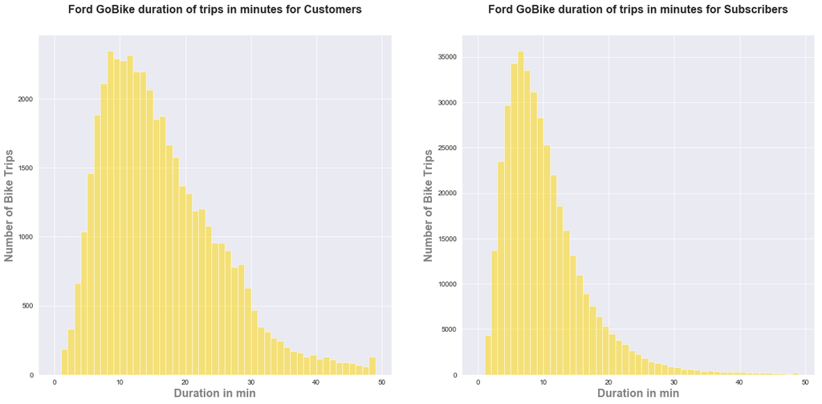

```python
# Customer Usage by Duration vs. Subscriber Usage by Duration in minuts and seconds.
plt.figure(figsize=(20,9))
plt.subplot(1, 2, 1)
xbins_min_cus = np.arange(0, 50)
plt.hist(data = df_clean.query('user_type == "Customer"'), x = 'duration_min', bins = xbins_min_cus, color= 'gold', alpha= 0.5);
sns.set_style("darkgrid")
plt.xlabel('Duration in min', fontsize = 16, fontweight = 'bold', color='grey')
plt.ylabel('Number of Bike Trips',fontsize = 16, fontweight = 'bold', color='grey')
plt.title('Ford GoBike duration of trips in minutes for Customers', y = 1.05, fontsize = 16, fontweight = 'bold')


plt.subplot(1, 2, 2)
xbins_min_sub = np.arange(0, 50)
plt.hist(data = df_clean.query('user_type == "Subscriber"'), x = 'duration_min', bins = xbins_min_sub, color= 'gold', alpha= 0.5);
sns.set_style("darkgrid")
plt.xlabel('Duration in min', fontsize = 16, fontweight = 'bold', color='grey')
plt.ylabel('Number of Bike Trips',fontsize = 16, fontweight = 'bold', color='grey')
plt.title('Ford GoBike duration of trips in minutes for Subscribers', y = 1.05, fontsize = 16, fontweight = 'bold')
```

```python
df_clean.query('user_type == "Subscriber"').duration_min.describe()
```

```
count    400701.000000
mean         11.261202
std          30.932101
min           1.000000
25%           5.000000
50%           8.000000
75%          13.000000
max        1434.000000
Name: duration_min, dtype: float64
```

```python
df_clean.query('user_type == "Customer"').duration_min.describe()
```

```
count    48533.000000
mean        30.964910
std         90.257276
min          1.000000
25%          9.000000
50%         15.000000
75%         23.000000
max       1437.000000
Name: duration_min, dtype: float64
```